# TempOrder_Exp2_Recall_Analysis

Yining Ding

2025-02-18

Dataset: 38 SONA participants collected in 2023/10. 6 were excluded, totaling 32 used in the actual analysis.

Input files:

- e165_Exp2_Recall_Scoring_Combined.xlsx (Scoring of recall data)
- e165_Exp2_Recall_NarrativeList_Psifr.xlsx (For creating recall data file format compatible for using Psifr package in Python)

Output file:

- e165_Exp2_Recall_Transition_Psifr.csv (compatible for using Psifr package in Python)

```r
library(readxl)
library(ggplot2)
library(dplyr)
library(tidyverse)
library(lme4)
library(lmerTest)
library(performance)
library(jtools)
library(optimx)
library(lsr)
library(emmeans)
library(sjPlot)
library(ggpubr)
library(mixedpower)
library(DHARMa)
library(glmmTMB)
library(nnet)
library(BayesFactor)
library(lattice)
library(plotrix)
library(moments)
library(car)
```

```r
# LMER Optimizers
cl_a <- lmerControl(optimizer = "bobyqa", optCtrl = list(maxfun = 1e+09))
cl_b <- lmerControl(optimizer = "Nelder_Mead", optCtrl = list(maxfun = 1e+09))
cl_c <- lmerControl(optimizer = "optimx", optCtrl = list(method = "nlminb",
    maxiter = 1e+09))
cl_d <- lmerControl(optimizer = "nloptwrap", optCtrl = list(maxfun = 1e+09))
```

```r
# GLMER Optimizers
cl1 <- glmerControl(optimizer = "bobyqa", calc.derivs = FALSE, optCtrl = list(maxfun = 1e+09), check.conv.grad = .makeCC("warning",
tol = 0.002, relTol = NULL), check.conv.singular = .makeCC(action = "message", tol = 1e-09), check.conv.hess = .makeCC(action = "warning", tol = 0.000001))
cl2 <- glmerControl(optimizer = "Nelder_Mead", calc.derivs = FALSE, optCtrl = list(maxfun = 1e+09), check.conv.grad = .makeCC("warning", tol = 0.002, relTol = NULL), check.conv.singular = .makeCC(action = "message", tol = 1e-09), check.conv.hess = .makeCC(action = "warning", tol = 0.000001))
cl3 <- glmerControl(optimizer = "optimx", calc.derivs = FALSE, optCtrl = list(method = "nlminb", maxiter = 1e+09), check.conv.grad = .makeCC("warning", tol = 0.002, relTol = NULL), check.conv.singular = .makeCC(action = "message", tol = 1e-09), check.conv.hess = .makeCC(action = "warning", tol = 0.000001))
cl4 <- glmerControl(optimizer = "nloptwrap", calc.derivs = FALSE, optCtrl = list(maxfun = 1e+09), check.conv.grad = .makeCC("warning", tol = 0.002, relTol = NULL), check.conv.singular = .makeCC(action = "message",
tol = 1e-09), check.conv.hess = .makeCC(action = "warning",
tol = 0.000001))
```

```r
# Read coded data
setwd("/Users/dcl/Library/CloudStorage/Box-Box/DCL_ARCHIVE/Documents/Events/exp165_TemporalOrder/Manuscript/Complete_Data/Data_Deidentification")
HC1_Aunt_raw <- read_excel("e165_Exp2_Recall_Scoring_Combined.xlsx", sheet = "HC1_Aunt")
HC2_Swimming_raw <- read_excel("e165_Exp2_Recall_Scoring_Combined.xlsx", sheet = "HC2_Swimming")
HC3_Morning_raw <- read_excel("e165_Exp2_Recall_Scoring_Combined.xlsx", sheet = "HC3_Morning")
LC1_Shopping_raw <- read_excel("e165_Exp2_Recall_Scoring_Combined.xlsx", sheet = "LC1_Shopping")
LC2_Cleaning_raw <- read_excel("e165_Exp2_Recall_Scoring_Combined.xlsx", sheet = "LC2_Cleaning")
LC3_Zoo_raw <- read_excel("e165_Exp2_Recall_Scoring_Combined.xlsx", sheet = "LC3_Zoo")
```

```r
HC1_Aunt <- HC1_Aunt_raw %>%
  # Select rows with contents (25 fine-level events in total)
  slice(1:25) %>%
  # Select columns that contain useful information
  dplyr::select(1:3, 37, 5:36)  %>%
  # Treat NAs as 0s
  mutate_all(~ifelse(is.na(.), 0, .)) %>%
  # Pivot df from wide to long format
  pivot_longer(cols = 5:36,names_to = "Subject",values_to ="Recall_Order") %>%
  # Treat NAs as 0s
  mutate_all(~ifelse(is.na(.), 0, .)) %>%
  # Filter events that were not recalled
  filter(Recall_Order != 0) %>%
  #Arrange according to the order of recall, group by subject
  arrange(Subject, Recall_Order) %>%
  # Add columns specifying Narrative_Type and Narrative
  mutate(Narrative_Type = "CS", Narrative = "HC1_Aunt") %>%
  # Add a column specifying narrative index and Coarse_List_index
  mutate(List_index = 1, Coarse_List_index = List_index * 10 + `Coarse-level_index`)

HC2_Swimming <- HC2_Swimming_raw %>%
  # Select rows with contents (25 fine-level events in total)
  slice(1:25) %>%
  # Select columns that contain useful information
  dplyr::select(1:3, 37, 5:36)  %>%
  # Treat NAs as 0s
  mutate_all(~ifelse(is.na(.), 0, .)) %>%
  # Pivot df from wide to long format
  pivot_longer(cols = 5:36,names_to = "Subject",values_to ="Recall_Order") %>%
  # Treat NAs as 0s
  mutate_all(~ifelse(is.na(.), 0, .)) %>%
  # Filter events that were not recalled
  filter(Recall_Order != 0) %>%
  #Arrange according to the order of recall, group by subject
  arrange(Subject, Recall_Order) %>%
  # Add columns specifying Narrative_Type and Narrative
  mutate(Narrative_Type = "CS", Narrative = "HC2_Swimming") %>%
  # Add a column specifying narrative index and Coarse_List_index
  mutate(List_index = 2, Coarse_List_index = List_index * 10 + `Coarse-level_index`)

HC3_Morning <- HC3_Morning_raw %>%
  # Select rows with contents (25 fine-level events in total)
  slice(1:25) %>%
  # Select columns that contain useful information
  dplyr::select(1:3, 37, 5:36)  %>%
  # Treat NAs as 0s
  mutate_all(~ifelse(is.na(.), 0, .)) %>%
  # Pivot df from wide to long format
  pivot_longer(cols = 5:36,names_to = "Subject",values_to ="Recall_Order") %>%
  # Treat NAs as 0s
  mutate_all(~ifelse(is.na(.), 0, .)) %>%
  # Filter events that were not recalled
  filter(Recall_Order != 0) %>%
  # Arrange according to the order of recall, group by subject
  arrange(Subject, Recall_Order) %>%
  # Add columns specifying Narrative_Type and Narrative
  mutate(Narrative_Type = "CS", Narrative = "HC3_Morning") %>%
  # Add a column specifying narrative index and Coarse_List_index
  mutate(List_index = 3, Coarse_List_index = List_index * 10 + `Coarse-level_index`)

LC1_Shopping <- LC1_Shopping_raw %>%
  # Select rows with contents (25 fine-level events in total)
  slice(1:25) %>%
  # Select columns that contain useful information
  dplyr::select(1:3, 37, 5:36)  %>%
  # Treat NAs as 0s
  mutate_all(~ifelse(is.na(.), 0, .)) %>%
  # Pivot df from wide to long format
  pivot_longer(cols = 5:36,names_to = "Subject",values_to ="Recall_Order") %>%
  # Treat NAs as 0s
  mutate_all(~ifelse(is.na(.), 0, .)) %>%
  # Filter events that were not recalled
  filter(Recall_Order != 0) %>%
  #Arrange according to the order of recall, group by subject
  arrange(Subject, Recall_Order) %>%
  # Add columns specifying Narrative_Type and Narrative
  mutate(Narrative_Type = "FS", Narrative = "LC1_Shopping") %>%
  # Add a column specifying narrative index and Coarse_List_index
  mutate(List_index = 4, Coarse_List_index = List_index * 10 + `Coarse-level_index`)

LC2_Cleaning <- LC2_Cleaning_raw %>%
  # Select rows with contents (25 fine-level events in total)
  slice(1:25) %>%
  # Select columns that contain useful information
  dplyr::select(1:3, 37, 5:36)  %>%
  # Treat NAs as 0s
  mutate_all(~ifelse(is.na(.), 0, .)) %>%
  # Pivot df from wide to long format
  pivot_longer(cols = 5:36,names_to = "Subject",values_to ="Recall_Order") %>%
  # Treat NAs as 0s
  mutate_all(~ifelse(is.na(.), 0, .)) %>%
  # Filter events that were not recalled
  filter(Recall_Order != 0) %>%
  #Arrange according to the order of recall, group by subject
  arrange(Subject, Recall_Order) %>%
  # Add columns specifying Narrative_Type and Narrative
  mutate(Narrative_Type = "FS", Narrative = "LC2_Cleaning") %>%
  # Add a column specifying narrative index and Coarse_List_index
  mutate(List_index = 5, Coarse_List_index = List_index * 10 + `Coarse-level_index`)

LC3_Zoo <- LC3_Zoo_raw %>%
  # Select rows with contents (25 fine-level events in total)
  slice(1:25) %>%
  # Select columns that contain useful information
  dplyr::select(1:3, 37, 5:36)  %>%
  # Treat NAs as 0s
  mutate_all(~ifelse(is.na(.), 0, .)) %>%
  # Pivot df from wide to long format
  pivot_longer(cols = 5:36,names_to = "Subject",values_to ="Recall_Order") %>%
  # Treat NAs as 0s
  mutate_all(~ifelse(is.na(.), 0, .)) %>%
  # Filter events that were not recalled
  filter(Recall_Order != 0) %>%
  #Arrange according to the order of recall, group by subject
  arrange(Subject, Recall_Order) %>%
  # Add columns specifying Narrative_Type and Narrative
  mutate(Narrative_Type = "FS", Narrative = "LC3_Zoo") %>%
  # Add a column specifying narrative index and Coarse_List_index
  mutate(List_index = 6, Coarse_List_index = List_index * 10 + `Coarse-level_index`)


# Split recall data by subject
splited_HC1_Aunt <- split(HC1_Aunt, HC1_Aunt$Subject)
splited_HC2_Swimming <- split(HC2_Swimming, HC2_Swimming$Subject)
splited_HC3_Morning <- split(HC3_Morning, HC3_Morning$Subject)
splited_LC1_Shopping <- split(LC1_Shopping, LC1_Shopping$Subject)
splited_LC2_Cleaning <- split(LC2_Cleaning, LC2_Cleaning$Subject)
splited_LC3_Zoo <- split(LC3_Zoo, LC3_Zoo$Subject)
```

```r
total_recall <- rbind(HC1_Aunt, HC2_Swimming, HC3_Morning, LC1_Shopping, LC2_Cleaning, LC3_Zoo)
# Treat Index, Subject, Narrative_Type, and Narrative as factors
#total_recall$`Fine-level_index` <- as.factor(total_recall$`Fine-level_index`)
#total_recall$`Fine-level_subindex` <- as.factor(total_recall$`Fine-level_subindex`)
total_recall$Subject <- as.numeric(total_recall$Subject)
total_recall$Narrative <- as.factor(total_recall$Narrative)
total_recall$Narrative_Type <- as.factor(total_recall$Narrative_Type)
# Column Subject_Coarse_List_index: Subject_index * 100 + Narrative_index * 10 + Coarse_level_index * 1
total_recall$Subject_Coarse_List_index <- 100*total_recall$Subject + total_recall$Coarse_List_index
```

```r
# Add a new column Fine_loc: loc of each fine-level event within each coarse-level event
total_recall <- total_recall %>%
  group_by(Subject_Coarse_List_index) %>%
  mutate(Fine_loc = row_number())
```

```r
# Number of coarse-level events recalled per narrative
num_coarse_summ <- total_recall %>% group_by(Subject, Narrative_Type, Narrative) %>%
  summarize(num_coarse = length(unique(`Coarse-level_index`)))
num_coarse_summ %>% group_by(Narrative_Type) %>%
  summarize(meanCoarseNum = mean(num_coarse))
```

| Narrative_Type | meanCoarseNum |
| --- | --- |
| CS | 4.389474 |
| FS | 4.032609 |

```r
mean(num_coarse_summ$num_coarse)
```

```
## [1] 4.213904
```

```r
sd(num_coarse_summ$num_coarse)
```

```
## [1] 1.056073
```

```r
total_recall_cleaned <- total_recall %>%
  dplyr::select(-`Fine-level_index`, -`Fine-level_event`, -`Recall_Order`)
total_recall_cleaned <- total_recall_cleaned %>%
  mutate(Fine_loc_name = case_when(
    Fine_loc == 1 ~ "recall_loc_1",
    Fine_loc == 2 ~ "recall_loc_2",
    Fine_loc == 3 ~ "recall_loc_3",
    Fine_loc == 4 ~ "recall_loc_4",
    Fine_loc == 5 ~ "recall_loc_5",
    TRUE ~ "OtherValue" # Default case
  ))
total_recall_cleaned <- total_recall_cleaned %>%
  dplyr::select(-Fine_loc)
total_recall_wider <- total_recall_cleaned %>%
  pivot_wider(names_from = "Fine_loc_name", values_from = "Fine-level_subindex")
total_recall_wider
```

| Coarse-level_index | Subject | Narrative_Type | Narrative | List_index | Coarse_List_index | Subject_Coarse_List_index | recall_loc_1 | recall_loc_2 | recall_loc_3 | recall_loc_4 | recall_loc_5 |
| --- | --- | --- | --- | --- | --- | --- | --- | --- | --- | --- | --- |
| 1 | 1 | CS | HC1_Aunt | 1 | 11 | 111 | 1 | 4 | NA | NA | NA |
| 2 | 1 | CS | HC1_Aunt | 1 | 12 | 112 | 3 | NA | NA | NA | NA |
| 3 | 1 | CS | HC1_Aunt | 1 | 13 | 113 | 4 | 3 | NA | NA | NA |
| 4 | 1 | CS | HC1_Aunt | 1 | 14 | 114 | 1 | NA | NA | NA | NA |
| 5 | 1 | CS | HC1_Aunt | 1 | 15 | 115 | 4 | 1 | NA | NA | NA |
| 1 | 10 | CS | HC1_Aunt | 1 | 11 | 1011 | 1 | 2 | 4 | 5 | NA |
| 2 | 10 | CS | HC1_Aunt | 1 | 12 | 1012 | 1 | 2 | 3 | 4 | 5 |
| 3 | 10 | CS | HC1_Aunt | 1 | 13 | 1013 | 1 | 2 | 3 | 4 | 5 |
| 4 | 10 | CS | HC1_Aunt | 1 | 14 | 1014 | 2 | 1 | 4 | 5 | NA |
| 5 | 10 | CS | HC1_Aunt | 1 | 15 | 1015 | 1 | 3 | 5 | 4 | NA |

[output cut: 778 more lines]

```r
# Use mutate to combine numeric values from multiple columns into a vector
total_recall_wider <- total_recall_wider %>%
  mutate(
    recall_loc_1 = ifelse(is.na(recall_loc_1), 0, recall_loc_1),
    recall_loc_2 = ifelse(is.na(recall_loc_2), 0, recall_loc_2),
    recall_loc_3 = ifelse(is.na(recall_loc_3), 0, recall_loc_3),
    recall_loc_4 = ifelse(is.na(recall_loc_4), 0, recall_loc_4),
    recall_loc_5 = ifelse(is.na(recall_loc_5), 0, recall_loc_5),
  ) %>%
  rowwise() %>%
  mutate(recall_vec = list(c(recall_loc_1, recall_loc_2, recall_loc_3, recall_loc_4, recall_loc_5))) %>%
  mutate(correct_vec = list(c(sort(recall_vec)))) %>%
  mutate(recall_vec_NZ = list(c(recall_vec[recall_vec != 0]))) %>%
  mutate(correct_vec_NZ = list(c(correct_vec[correct_vec != 0])))
total_recall_wider
```

| Coarse-level_index | Subject | Narrative_Type | Narrative | List_index | Coarse_List_index | Subject_Coarse_List_index | recall_loc_1 | recall_loc_2 | recall_loc_3 | recall_loc_4 | recall_loc_5 | recall_vec | correct_vec | recall_vec_NZ | correct_vec_NZ |
| --- | --- | --- | --- | --- | --- | --- | --- | --- | --- | --- | --- | --- | --- | --- | --- |
| 1 | 1 | CS | HC1_Aunt | 1 | 11 | 111 | 1 | 4 | 0 | 0 | 0 |  |  |  |  |
| 2 | 1 | CS | HC1_Aunt | 1 | 12 | 112 | 3 | 0 | 0 | 0 | 0 |  |  |  |  |
| 3 | 1 | CS | HC1_Aunt | 1 | 13 | 113 | 4 | 3 | 0 | 0 | 0 |  |  |  |  |
| 4 | 1 | CS | HC1_Aunt | 1 | 14 | 114 | 1 | 0 | 0 | 0 | 0 |  |  |  |  |
| 5 | 1 | CS | HC1_Aunt | 1 | 15 | 115 | 4 | 1 | 0 | 0 | 0 |  |  |  |  |
| 1 | 10 | CS | HC1_Aunt | 1 | 11 | 1011 | 1 | 2 | 4 | 5 | 0 |  |  |  |  |
| 2 | 10 | CS | HC1_Aunt | 1 | 12 | 1012 | 1 | 2 | 3 | 4 | 5 |  |  |  |  |
| 3 | 10 | CS | HC1_Aunt | 1 | 13 | 1013 | 1 | 2 | 3 | 4 | 5 |  |  |  |  |
| 4 | 10 | CS | HC1_Aunt | 1 | 14 | 1014 | 2 | 1 | 4 | 5 | 0 |  |  |  |  |
| 5 | 10 | CS | HC1_Aunt | 1 | 15 | 1015 | 1 | 3 | 5 | 4 | 0 |  |  |  |  |

[output cut: 778 more lines]

```r
# Write a helper function for computing deviation score
compute_dev_score <- function(recall_vec, correct_vec){
  length = length(recall_vec)
  dev_score = 0
  if (length == 1){
    return(dev_score)
  }
  for (i in 1:(length - 1)){
    j = i + 1
    dev_score = dev_score + abs((correct_vec[j] - correct_vec[i]) - (recall_vec[j] - recall_vec[i]))
  }
  return (dev_score)
}

# Compute Deviation Score
total_recall_wider <- total_recall_wider %>%
  rowwise() %>%
  mutate(dev_score = compute_dev_score(recall_vec_NZ, correct_vec_NZ))

# Compute the length of each coarse-level list
total_recall_wider <- total_recall_wider %>%
  rowwise() %>%
  mutate(recall_vec_length = length(recall_vec_NZ))

# Compute the normalized Deviation Score (by dividing Deviation Score by the number of transitions in each list)
total_recall_wider <- total_recall_wider %>%
  rowwise() %>%
  mutate(norm_dev_score = dev_score / (recall_vec_length-1))

# Filter out excluded trial
total_recall_wider <- total_recall_wider %>%
  filter(!(Subject == 2 & Narrative == "HC1_Aunt"))
```

```r
total_recall_wider <- total_recall_wider %>%
  rowwise() %>%
  mutate(corr = abs(cor(recall_vec_NZ, correct_vec_NZ)))
```

```r
total_recall_wider <- total_recall_wider %>%
  mutate(order_correct = ifelse(norm_dev_score == 0, 1, 0))
```

### Analysis 1: Number of Events Recalled

#### 1.1 Fine-level Events Per Narrative (CS vs. FS)

Hypothesis: The average number of fine-level events recalled per narrative for FS narratives will be more than for CS narratives.

```r
total_recall_fine <- total_recall_wider %>%
  group_by(Subject, Narrative) %>%
  summarize(narr_total = sum(recall_vec_length),
            Narrative_Type = Narrative_Type,
            .groups = "drop") %>%
  as.data.frame()

total_recall_fine_distinct <- distinct(total_recall_fine)
total_recall_fine_distinct$Narrative <- as.factor(total_recall_fine_distinct$Narrative)
total_recall_fine_distinct
```

| Subject | Narrative | narr_total | Narrative_Type |
| --- | --- | --- | --- |
| 1 | HC1_Aunt | 8 | CS |
| 1 | HC2_Swimming | 12 | CS |
| 1 | HC3_Morning | 8 | CS |
| 1 | LC1_Shopping | 10 | FS |
| 1 | LC2_Cleaning | 1 | FS |
| 1 | LC3_Zoo | 9 | FS |
| 2 | HC2_Swimming | 11 | CS |
| 2 | HC3_Morning | 13 | CS |
| 2 | LC1_Shopping | 16 | FS |
| 2 | LC2_Cleaning | 9 | FS |

[output cut: 176 more lines]

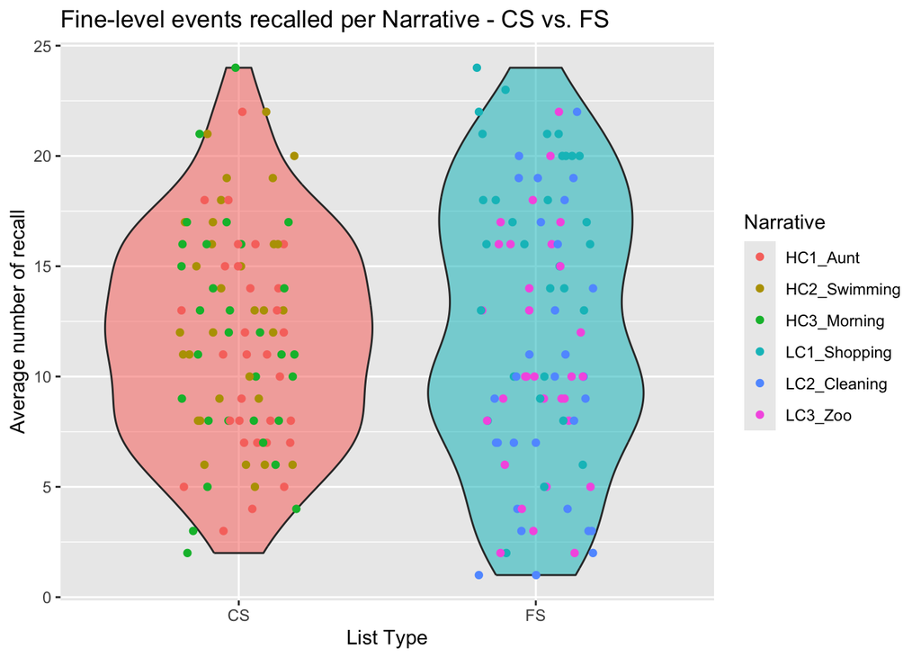

```r
total_recall_fine_distinct %>% ggplot(aes(x = Narrative_Type, y = narr_total)) +
  geom_violin(aes(fill = Narrative_Type, alpha = .3), show.legend = FALSE) +
  geom_jitter(position = position_jitter(height=0, width=0.2), aes(color = Narrative)) +
  labs(title = 'Fine-level events recalled per Narrative - CS vs. FS', x = 'List Type', y = 'Average number of recall')
```

```r
# Group Difference by Subjects
narr_total_summ_bySubj <- total_recall_fine_distinct %>%
  group_by(Subject, Narrative_Type) %>%
  summarize(mean_narr_total = mean(narr_total))
```

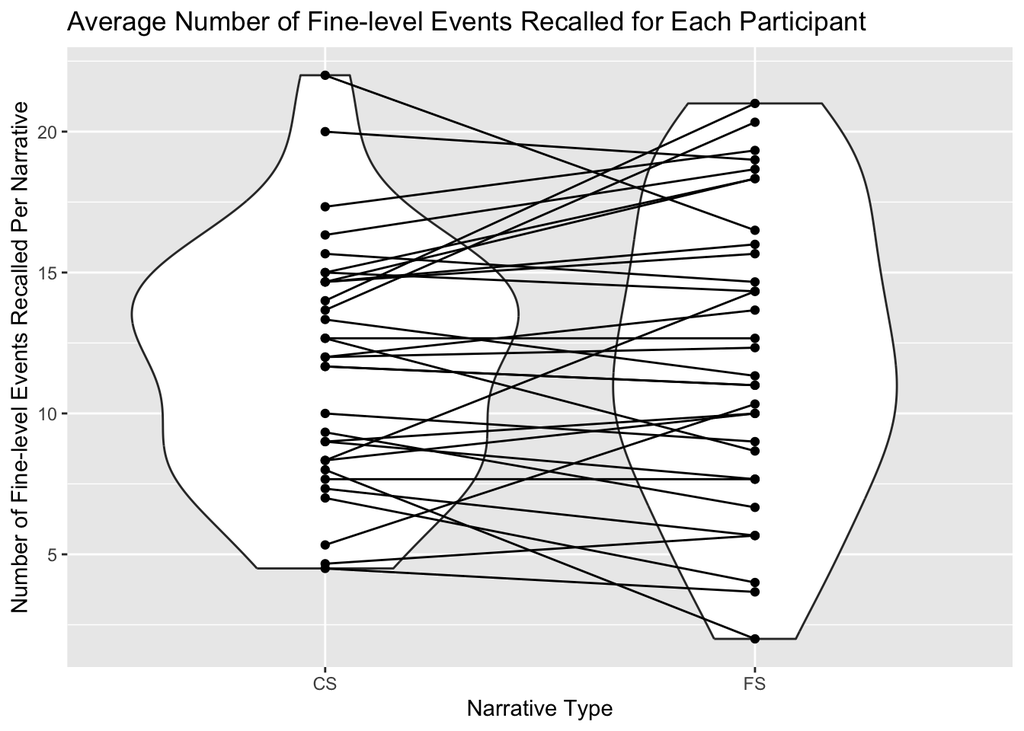

```r
#narr_total_summ_bySubj$Subject <- as.factor(narr_total_summ_bySubj$Subject)

narr_total_summ_bySubj %>%
  ggplot(aes(x = Narrative_Type, y = mean_narr_total, fill = Subject)) +
  geom_violin() +
  geom_point() +
  geom_line(aes(group = Subject)) +
  theme(legend.position = "none") +
  labs(x = "Narrative Type", y = "Number of Fine-level Events Recalled Per Narrative", title = "Average Number of Fine-level Events Recalled for Each Participant")
```

```r
mean(total_recall_fine_distinct$narr_total)
```

```
## [1] 12.00538
```

```r
sd(total_recall_fine_distinct$narr_total)
```

```
## [1] 5.543438
```

```r
std.error(total_recall_fine_distinct$narr_total)
```

```
## [1] 0.4064646
```

```r
# Model 1: Random Slope for Subject, Random Intercept for Narrative
NumFinePerNarr_subSlope_narrIntercept_model <- lmer(narr_total ~ Narrative_Type + (Narrative_Type|Subject) + (1| Narrative), data = total_recall_fine_distinct)
#summ(NumFinePerNarr_subSlope_narrIntercept_model, digits = getOption("jtools-digits", 4))
# Model 2: Random Intercept for Subject and Narrative
NumFinePerNarr_subStim_Intercept_model <- lmer(narr_total ~ Narrative_Type + (1 |Subject) + (1| Narrative), data = total_recall_fine_distinct)
```

```r
# Model Comparison: Select Model 2 - Random Intercept for Subject and Narrative
anova(NumFinePerNarr_subStim_Intercept_model, NumFinePerNarr_subSlope_narrIntercept_model)
```

```
## refitting model(s) with ML (instead of REML)
```

|  | npar | AIC | BIC | logLik | deviance | Chisq | Df | Pr(>Chisq) |
| --- | --- | --- | --- | --- | --- | --- | --- | --- |
| NumFinePerNarr_subStim_Intercept_model | 5 | 1061.50 | 1077.628 | -525.7498 | 1051.50 | NA | NA | NA |
| NumFinePerNarr_subSlope_narrIntercept_model | 7 | 1059.73 | 1082.310 | -522.8651 | 1045.73 | 5.769365 | 2 | 0.05587254 |

```r
# Summary of Model 2
summ(NumFinePerNarr_subStim_Intercept_model, digits = getOption("jtools-digits", 4))
```

```
## MODEL INFO:
## Observations: 186
## Dependent Variable: narr_total
## Type: Mixed effects linear regression
##
## MODEL FIT:
## AIC = 1056.7969, BIC = 1072.9256
## Pseudo-R² (fixed effects) = 0.0010
## Pseudo-R² (total) = 0.6844
##
## FIXED EFFECTS:
## --------------------------------------------------------------------
##                             Est.     S.E.   t val.     d.f.        p
## ---------------------- --------- -------- -------- -------- --------
## (Intercept)              11.7916   1.4099   8.3633   7.7372   0.0000
## Narrative_TypeFS          0.3620   1.6797   0.2155   3.9963   0.8399
## --------------------------------------------------------------------
##
## p values calculated using Satterthwaite d.f.
##
## RANDOM EFFECTS:
## -------------------------------------
##    Group      Parameter    Std. Dev.
## ----------- ------------- -----------
##   Subject    (Intercept)    4.3033
##  Narrative   (Intercept)    1.9738
##  Residual                   3.2177
## -------------------------------------
##
## Grouping variables:
## -------------------------------
##    Group     # groups    ICC
## ----------- ---------- --------
##   Subject       32      0.5651
##  Narrative      6       0.1189
## -------------------------------
```

```r
anova(NumFinePerNarr_subStim_Intercept_model)
```

|  | Sum Sq | Mean Sq | NumDF | DenDF | F value | Pr(>F) |
| --- | --- | --- | --- | --- | --- | --- |
| Narrative_Type | 0.4809964 | 0.4809964 | 1 | 3.996308 | 0.0464574 | 0.8399002 |

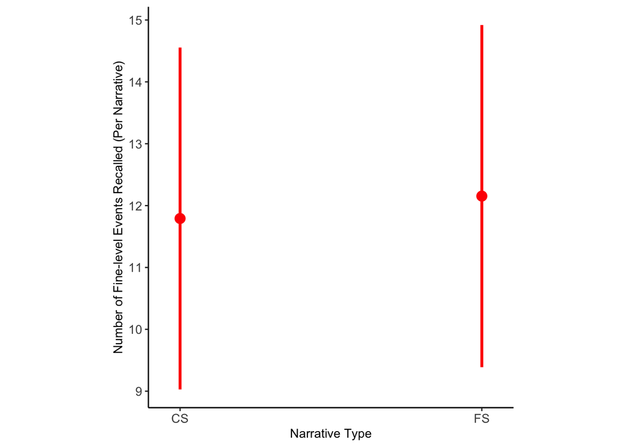

```r
# Plot Main Effect of Narrative Type:
plot_model(NumFinePerNarr_subStim_Intercept_model, type = "emm", terms = c("Narrative_Type"), colors = c("red"), dot.size = 3.5, line.size = 1.1, axis.labels = c("CS Narrative", "FS Narrative")) +
  theme_classic() +
  theme(aspect.ratio = 1.1, axis.text = element_text(size = 10), axis.title = element_text(size = 10)) +
  #aes(color=group) +
  #font_size(axis_title.x = 13, axis_title.y = 13,labels.x = 14, labels.y = 14) +
  labs(x = "Narrative Type", y = "Number of Fine-level Events Recalled (Per Narrative)", title = NULL, size = 10)
```

```r
# Check model residual
#simulationOutput_NumFinePerNarr <- simulateResiduals(fittedModel = NumFinePerNarr_subStim_Intercept_model, plot = F)
#plot(simulationOutput_NumFinePerNarr)
```

```r
total_recall_fine_distinct$Subject <- as.factor(total_recall_fine_distinct$Subject)
total_recall_fine_distinct$Narrative <- as.factor(total_recall_fine_distinct$Narrative)
total_recall_fine_distinct$Narrative_Type <- as.factor(total_recall_fine_distinct$Narrative_Type)

#Calculate the BF
BF0 <- lmBF(narr_total ~ 1 + Subject + Narrative, data = total_recall_fine_distinct, whichRandom = c("Subject", "Narrative"))
BF1 <- lmBF(narr_total ~ Narrative_Type + Subject + Narrative, data = total_recall_fine_distinct, whichRandom = c("Subject", "Narrative"))
BF1 / BF0
```

```
## Bayes factor analysis
## --------------
## [1] Narrative_Type + Subject + Narrative : 0.4824961 ±1.2%
##
## Against denominator:
##   narr_total ~ 1 + Subject + Narrative
## ---
## Bayes factor type: BFlinearModel, JZS
```

#### 1.2 Fine-level Events Per Coarse-level Event (CS vs. FS)

Hypothesis: The average number of fine-level events recalled per coarse-level event for FS narratives will be more than for CS narratives.

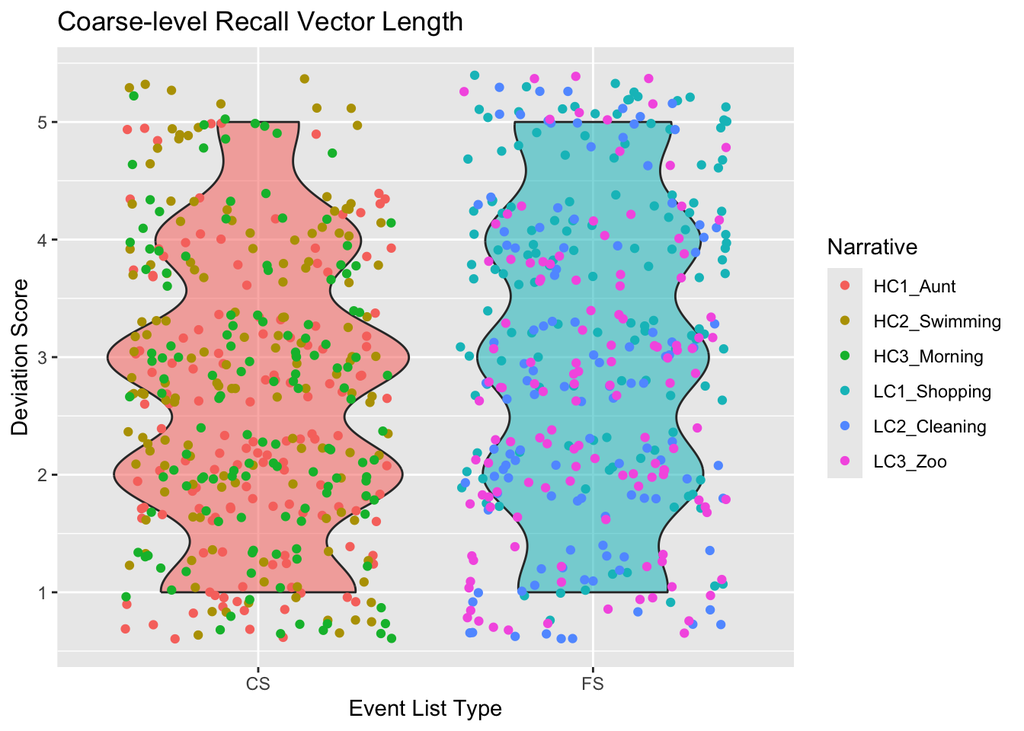

```r
total_recall_wider %>%
  ggplot(aes(x = Narrative_Type, y = recall_vec_length)) +
  geom_violin(aes(fill = Narrative_Type, alpha = .3), show.legend = FALSE) +
  geom_jitter(aes(color = Narrative)) +
  labs(title = 'Coarse-level Recall Vector Length', x = 'Event List Type', y = 'Deviation Score')
```

```r
mean(total_recall_wider$recall_vec_length)
```

```
## [1] 2.851852
```

```r
sd(total_recall_wider$recall_vec_length)
```

```
## [1] 1.254564
```

```r
std.error(total_recall_wider$recall_vec_length)
```

```
## [1] 0.04483448
```

```r
# Model 1: Subject and Narrative as random intercept
NumFinePerCoarse_subStim_Intercept_model <- lmer(recall_vec_length ~ Narrative_Type + (1|Subject) + (1|Narrative), data = total_recall_wider)
summ(NumFinePerCoarse_subStim_Intercept_model, digits = getOption("jtools-digits", 4))
```

```
## MODEL INFO:
## Observations: 783
## Dependent Variable: recall_vec_length
## Type: Mixed effects linear regression
##
## MODEL FIT:
## AIC = 2391.7432, BIC = 2415.0589
## Pseudo-R² (fixed effects) = 0.0119
## Pseudo-R² (total) = 0.3359
##
## FIXED EFFECTS:
## --------------------------------------------------------------------
##                            Est.     S.E.    t val.     d.f.        p
## ---------------------- -------- -------- --------- -------- --------
## (Intercept)              2.6235   0.2386   10.9962   6.5381   0.0000
## Narrative_TypeFS         0.2803   0.2974    0.9424   4.0026   0.3993
## --------------------------------------------------------------------
##
## p values calculated using Satterthwaite d.f.
##
## RANDOM EFFECTS:
## -------------------------------------
##    Group      Parameter    Std. Dev.
## ----------- ------------- -----------
##   Subject    (Intercept)    0.6406
##  Narrative   (Intercept)    0.3523
##  Residual                   1.0466
## -------------------------------------
##
## Grouping variables:
## -------------------------------
##    Group     # groups    ICC
## ----------- ---------- --------
##   Subject       32      0.2518
##  Narrative      6       0.0762
## -------------------------------
```

```r
anova(NumFinePerCoarse_subStim_Intercept_model)
```

|  | Sum Sq | Mean Sq | NumDF | DenDF | F value | Pr(>F) |
| --- | --- | --- | --- | --- | --- | --- |
| Narrative_Type | 0.9727266 | 0.9727266 | 1 | 4.0026 | 0.888052 | 0.399331 |

```r
#simulationOutput_NumFinePerCoarse <- simulateResiduals(fittedModel = NumFinePerCoarse_subStim_Intercept_model, plot = F)
#plot(simulationOutput_NumFinePerCoarse)
```

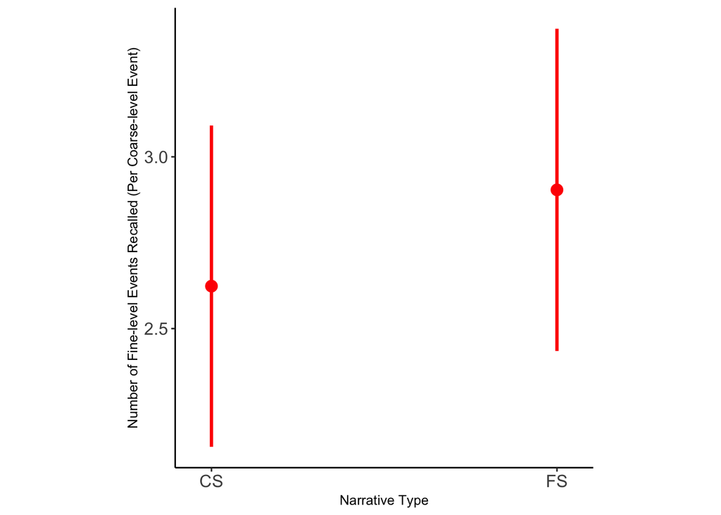

```r
# Plot Main Effect of Narrative Type:
plot_model(NumFinePerCoarse_subStim_Intercept_model, type = "emm", terms = c("Narrative_Type"), colors = c("red"), dot.size = 3.5, line.size = 1.1, axis.labels = c("CS Narrative", "FS Narrative")) +
  theme_classic() +
  theme(aspect.ratio = 1.1, axis.text = element_text(size = 12), axis.title = element_text(size = 9.5)) +
  #aes(color=group) +
  #font_size(axis_title.x = 13, axis_title.y = 13,labels.x = 14, labels.y = 14) +
  labs(x = "Narrative Type", y = "Number of Fine-level Events Recalled (Per Coarse-level Event)", title = NULL, size = 10)
```

```r
total_recall_wider_df <- subset(total_recall_wider, select = -c(recall_vec, correct_vec, recall_vec_NZ, correct_vec_NZ))
total_recall_wider_df$Subject <- as.factor(total_recall_wider_df$Subject)
total_recall_wider_df$Narrative <- as.factor(total_recall_wider_df$Narrative)
total_recall_wider_df$Narrative_Type <- as.factor(total_recall_wider_df$Narrative_Type)

#Calculate the BF
BF0 <- lmBF(recall_vec_length ~ 1 + Subject + Narrative, data = total_recall_wider_df, whichRandom = c("Subject", "Narrative"))
BF1 <- lmBF(recall_vec_length ~ Narrative_Type + Subject + Narrative, data = total_recall_wider_df, whichRandom = c("Subject", "Narrative"))
BF1 / BF0
```

```
## Bayes factor analysis
## --------------
## [1] Narrative_Type + Subject + Narrative : 0.4460695 ±0.9%
##
## Against denominator:
##   recall_vec_length ~ 1 + Subject + Narrative
## ---
## Bayes factor type: BFlinearModel, JZS
```

### Analysis 2. Order of Events Recalled

#### 2.1 Deviance Score for each coarse-level list (CS vs. FS)

Hypothesis: Fine-level events within the same coarse-level event will be recalled less in order for CS narratives than for FS narratives.

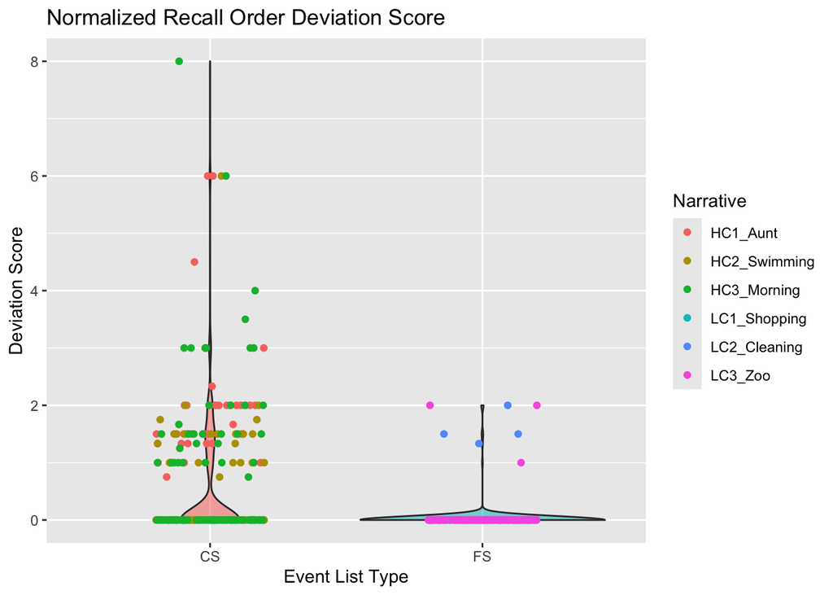

```r
norm_dev_score_graph <- total_recall_wider %>%
  ggplot(aes(x = Narrative_Type, y = norm_dev_score)) +
  geom_violin(aes(fill = Narrative_Type, alpha = .3), show.legend = FALSE) +
  geom_jitter(position = position_jitter(height=0, width=0.2), aes(color = Narrative)) +
  labs(title = 'Normalized Recall Order Deviation Score', x = 'Event List Type', y = 'Deviation Score')

norm_dev_score_graph
```

```r
mean(na.omit((total_recall_wider$norm_dev_score)))
```

```
## [1] 0.3064516
```

```r
sd(na.omit((total_recall_wider$norm_dev_score)))
```

```
## [1] 0.8546395
```

```r
std.error(na.omit((total_recall_wider$norm_dev_score)))
```

```
## [1] 0.03349596
```

```r
# Model 1: Both subject and narrative random intercept (Only this model fits!)
NormDevScore_Intercept_model <- lmer(norm_dev_score ~ Narrative_Type + (1|Subject) + (1|Narrative), data = total_recall_wider)
summ(NormDevScore_Intercept_model, digits = getOption("jtools-digits", 4))
```

```
## MODEL INFO:
## Observations: 651
## Dependent Variable: norm_dev_score
## Type: Mixed effects linear regression
##
## MODEL FIT:
## AIC = 1591.5767, BIC = 1613.9692
## Pseudo-R² (fixed effects) = 0.0932
## Pseudo-R² (total) = 0.1174
##
## FIXED EFFECTS:
## ---------------------------------------------------------------------
##                             Est.     S.E.    t val.     d.f.        p
## ---------------------- --------- -------- --------- -------- --------
## (Intercept)               0.5648   0.0833    6.7782   4.1581   0.0021
## Narrative_TypeFS         -0.5238   0.1177   -4.4508   4.1561   0.0103
## ---------------------------------------------------------------------
##
## p values calculated using Satterthwaite d.f.
##
## RANDOM EFFECTS:
## -------------------------------------
##    Group      Parameter    Std. Dev.
## ----------- ------------- -----------
##   Subject    (Intercept)    0.0561
##  Narrative   (Intercept)    0.1213
##  Residual                   0.8062
## -------------------------------------
##
## Grouping variables:
## -------------------------------
##    Group     # groups    ICC
## ----------- ---------- --------
##   Subject       32      0.0047
##  Narrative      6       0.0220
## -------------------------------
```

```r
anova(NormDevScore_Intercept_model)
```

|  | Sum Sq | Mean Sq | NumDF | DenDF | F value | Pr(>F) |
| --- | --- | --- | --- | --- | --- | --- |
| Narrative_Type | 12.87595 | 12.87595 | 1 | 4.156075 | 19.80944 | 0.01030139 |

```r
emmeans(NormDevScore_Intercept_model, pairwise ~ Narrative_Type, adjust = "none")
```

```
## $emmeans
##  Narrative_Type emmean     SE   df lower.CL upper.CL
##  CS             0.5648 0.0834 4.00    0.333    0.796
##  FS             0.0409 0.0846 4.19   -0.190    0.271
##
## Degrees-of-freedom method: kenward-roger
## Confidence level used: 0.95
##
## $contrasts
##  contrast estimate    SE   df t.ratio p.value
##  CS - FS     0.524 0.118 3.99   4.447  0.0113
##
## Degrees-of-freedom method: kenward-roger
```

```r
# Model 2: Subject random slope, Narrative random intercept (Does not converge)
NormDevScore_SubSlope_model <- lmer(norm_dev_score ~ Narrative_Type + (Narrative_Type|Subject) + (1|Narrative), data = total_recall_wider, control = cl_d)
```

```
## boundary (singular) fit: see help('isSingular')
```

```r
#summ(NormDevScore_SubSlope_model, digits = getOption("jtools-digits", 4))

# Model 3: Narrative random slope, Subject random intercept (Does not converge)
NormDevScore_NarrSlope_model <- lmer(norm_dev_score ~ Narrative_Type + (1|Subject) + (Narrative_Type|Narrative), data = total_recall_wider, control = cl_d)
```

```
## boundary (singular) fit: see help('isSingular')
```

```r
#summ(NormDevScore_NarrSlope_model, digits = getOption("jtools-digits", 4))

# Model 4: Narrative random slope, Subject random intercept (Does not converge)
NormDevScore_SubNarrSlope_model <- lmer(norm_dev_score ~ Narrative_Type + (Narrative_Type|Subject) + (Narrative_Type|Narrative), data = total_recall_wider, control = cl_d)
```

```
## boundary (singular) fit: see help('isSingular')
```

```r
#summ(NormDevScore_SubNarrSlope_model, digits = getOption("jtools-digits", 4))
```

```r
set_theme(base = theme_classic(), #To remove the background color and the grids
          title.size = 1,
          axis.tickslen = 0.2,
          axis.ticksmar = 0.4,
          legend.inside = TRUE,
          geom.label.size = 7,
          axis.title.size = 1.2,  #To change axis title size
          axis.textsize.x = 1.1,  #To change x axis text size
          axis.textsize.y = 1.1)  #To change y axis text size
```

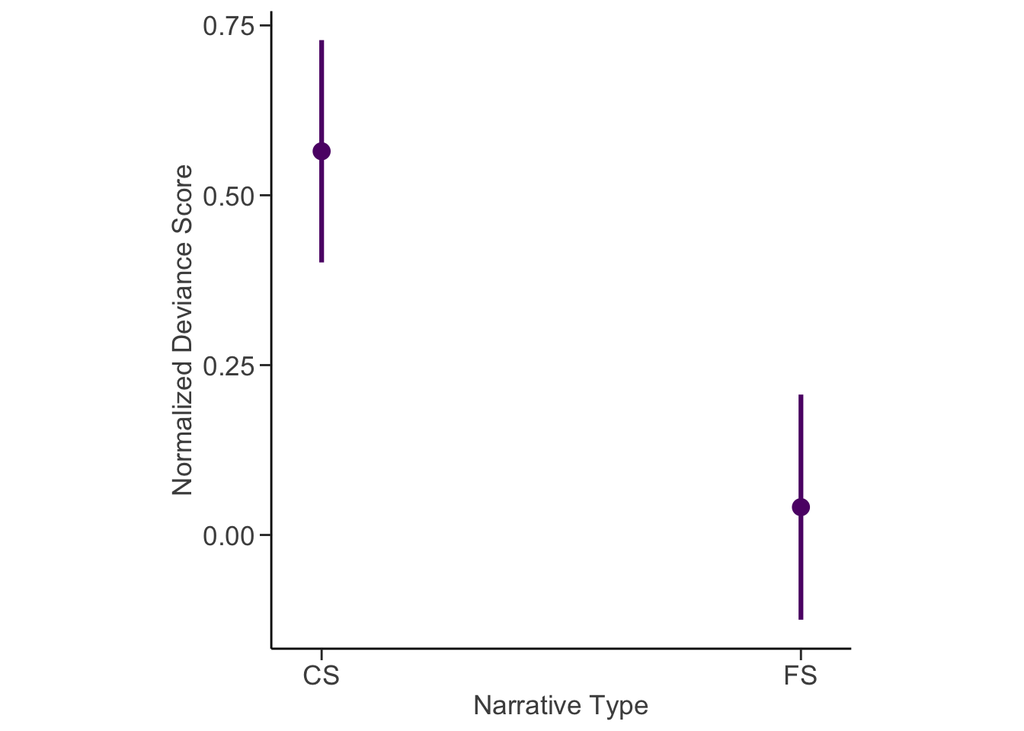

```r
# Plot Main Effect of Narrative Type:
plot_model(NormDevScore_Intercept_model, type = "eff", terms = c("Narrative_Type"), colors = c("#5E1675"), dot.size = 3.5, line.size = 1.1, axis.labels = c("CS Narrative", "FS Narrative")) +
  theme(aspect.ratio = 1.1, axis.text = element_text(size = 12)) +
  #aes(color=group) +
  #font_size(axis_title.x = 13, axis_title.y = 13,labels.x = 14, labels.y = 14) +
  labs(x = "Narrative Type", y = "Normalized Deviance Score", title = NULL)
```

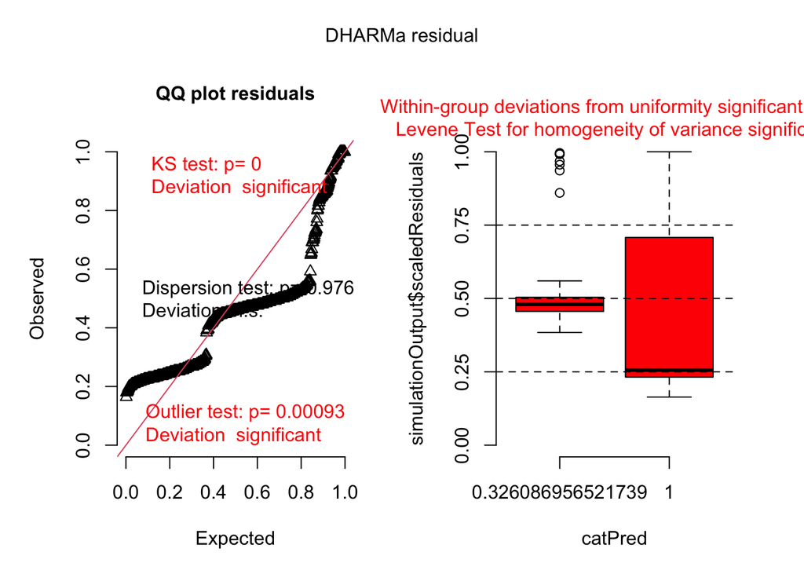

```r
# Check residual distribution
simulationOutput_NormDevScore_Intercept_model <- simulateResiduals(fittedModel = NormDevScore_Intercept_model, plot = F)
plot(simulationOutput_NormDevScore_Intercept_model)
```

#### Additional Analysis: Fit a logistic regression model for deviance score

Yields converging evidence with the linear regression model!

```r
#table(total_recall_wider$Narrative_Type, total_recall_wider$norm_dev_score)
noNA_total_recall_wider <- total_recall_wider %>% filter(!is.na(norm_dev_score))
table(noNA_total_recall_wider$Narrative_Type, noNA_total_recall_wider$norm_dev_score)
```

```
##
##        0 0.75   1 1.25 1.33333333333333 1.5 1.66666666666667 1.75   2
##   CS 239    3  19    1                9  27                2    2  18
##   FS 307    0   1    0                1   2                0    0   3
##
##      2.33333333333333   3 3.5   4 4.5   6   8
##   CS                1   8   1   1   1   4   1
##   FS                0   0   0   0   0   0   0
```

```r
table(noNA_total_recall_wider$Narrative_Type)
```

```
##
##  CS  FS
## 337 314
```

```r
(239+307)/(337+314) # percentage of 0s in the data
```

```
## [1] 0.8387097
```

```r
# Logistic Reg Model:
LogisticReg_Intercept_model <- glmer(order_correct ~ Narrative_Type + (1|Subject) + (1|Narrative), data = total_recall_wider, control = cl1, family = binomial)
summ(LogisticReg_Intercept_model, digits = getOption("jtools-digits", 4))
```

```
## MODEL INFO:
## Observations: 651
## Dependent Variable: order_correct
## Type: Mixed effects generalized linear regression
## Error Distribution: binomial
## Link function: logit
##
## MODEL FIT:
## AIC = 480.5346, BIC = 498.4486
## Pseudo-R² (fixed effects) = 0.3861
## Pseudo-R² (total) = 0.3949
##
## FIXED EFFECTS:
## ----------------------------------------------------------
##                            Est.     S.E.   z val.        p
## ---------------------- -------- -------- -------- --------
## (Intercept)              0.8939   0.1743   5.1277   0.0000
## Narrative_TypeFS         2.8975   0.4417   6.5593   0.0000
## ----------------------------------------------------------
##
## RANDOM EFFECTS:
## -------------------------------------
##    Group      Parameter    Std. Dev.
## ----------- ------------- -----------
##   Subject    (Intercept)    0.0000
##  Narrative   (Intercept)    0.2186
## -------------------------------------
##
## Grouping variables:
## -------------------------------
##    Group     # groups    ICC
## ----------- ---------- --------
##   Subject       32      0.0000
##  Narrative      6       0.0143
## -------------------------------
```

```r
Anova(LogisticReg_Intercept_model, type = "III")
```

|  | Chisq | Df | Pr(>Chisq) |
| --- | --- | --- | --- |
| (Intercept) | 26.29320 | 1 | 2.933200e-07 |
| Narrative_Type | 43.02495 | 1 | 5.404624e-11 |

```r
table(total_recall_wider$Narrative_Type, total_recall_wider$order_correct)
```

```
##
##        0   1
##   CS  98 239
##   FS   7 307
```

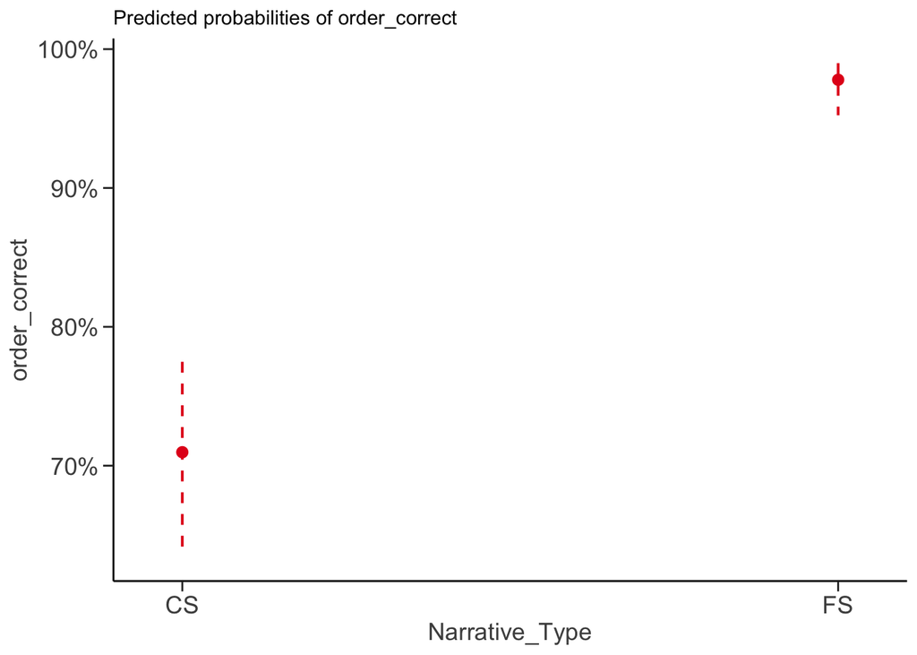

```r
plot_model(LogisticReg_Intercept_model, type = "pred")
```

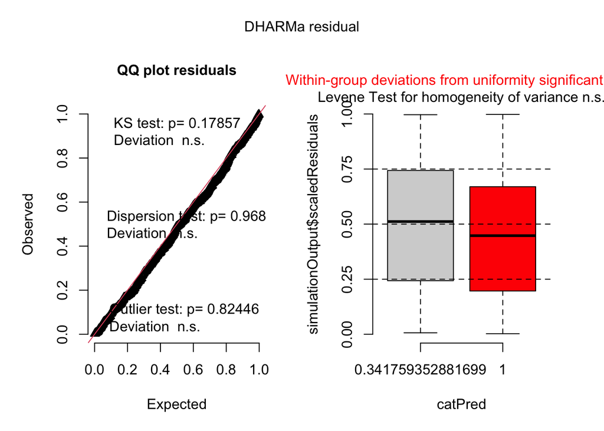

```r
# LogisticReg Model Diagnostics
simulationOutput_LogisticReg_Intercept_model <- simulateResiduals(fittedModel = LogisticReg_Intercept_model, plot = F)
plot(simulationOutput_LogisticReg_Intercept_model)
```

### Analysis 3: Recall Event Transition

#### 3.1: Positive Transition Probability

Hypothesis: The probability of making positive transitions for within-event transitions in CS narratives (CS_within) will be lower than the percentage of positive transitions for within-event transitions in FS narratives (FS_within) or across-event transitions in CS narratives (CS_across).

```r
# Construct a dataframe to store all the extracted recall pairs
complete_recallPairs <- data.frame(
  Subject = numeric(0),
  Narrative_Type = character(0),
  Narrative = character(0),
  Recall_lag = numeric(0),
  Script_lag = numeric(0),
  Correct = numeric(0),
  Recall_1 = numeric(0),
  Recall_2 = numeric(0),
  Script_1 = numeric(0),
  Script_2 = numeric(0),
  Script_coarse_1 = numeric(0),
  Script_coarse_2 = numeric(0)
)
complete_recallPairs
```

| Subject | Narrative_Type | Narrative | Recall_lag | Script_lag | Correct | Recall_1 | Recall_2 | Script_1 | Script_2 | Script_coarse_1 | Script_coarse_2 |
| --- | --- | --- | --- | --- | --- | --- | --- | --- | --- | --- | --- |

```r
# Define function to extract recall pairs
extract_recallPairs <- function(recall_pair_df, list_name, narrative_type, narrative_name){
  for (i in 1:length(list_name)){
  # Access the recall dataframe of each Subject i
  current_recall <- list_name[[i]]
    # Traverse through the list
    for (j in 1:(nrow(current_recall)-1)){
      # Make sure index does not exceed list length
      row_1 <- current_recall[j, ]
      row_2 <- current_recall[j+1, ]

      Recall_val_1 <- row_1[1, "Recall_Order"]
      Recall_val_2 <- row_2[1, "Recall_Order"]
      Script_val_1 <- row_1[1, "Fine-level_index"]
      Script_val_2 <- row_2[1, "Fine-level_index"]
      Script_coarse_1 <- row_1[1, "Coarse-level_index"]
      Script_coarse_2 <- row_2[1, "Coarse-level_index"]

      new_row <- list(Subject = i,
                      Narrative_Type = narrative_type,  # change type
                      Narrative = narrative_name,  # change name
                      Recall_lag = 0,
                      Script_lag = Script_val_2[[1, 1]] - Script_val_1[[1, 1]], #???
                      Correct = ifelse((Script_val_2[[1, 1]] - Script_val_1[[1, 1]]) > 0, 1, 0),
                      Recall_1 = Recall_val_1[[1, 1]],
                      Recall_2 = Recall_val_2[[1, 1]],
                      Script_1 = Script_val_1[[1, 1]],
                      Script_2 = Script_val_2[[1, 1]],
                      Script_coarse_1 = Script_coarse_1[[1, 1]],
                      Script_coarse_2 = Script_coarse_2[[1, 1]])

     recall_pair_df <- rbind(recall_pair_df, new_row)
     }
  }
  return(recall_pair_df)
}
```

```r
# Add HC1_Aunt Pairs to complete_recallPairs
complete_recallPairs <- extract_recallPairs(complete_recallPairs, splited_HC1_Aunt, "CS", "HC1_Aunt")
# Add HC1_Aunt Pairs to complete_recallPairs
complete_recallPairs <- extract_recallPairs(complete_recallPairs, splited_HC2_Swimming, "CS", "HC2_Swimming")
# Add HC1_Aunt Pairs to complete_recallPairs
complete_recallPairs <- extract_recallPairs(complete_recallPairs, splited_HC3_Morning, "CS", "HC3_Morning")
# Add HC1_Aunt Pairs to complete_recallPairs
complete_recallPairs <- extract_recallPairs(complete_recallPairs, splited_LC1_Shopping, "FS", "LC1_Shopping")
# Add HC1_Aunt Pairs to complete_recallPairs
complete_recallPairs <- extract_recallPairs(complete_recallPairs, splited_LC2_Cleaning, "FS", "LC2_Cleaning")
# Add HC1_Aunt Pairs to complete_recallPairs
complete_recallPairs <- extract_recallPairs(complete_recallPairs, splited_LC3_Zoo, "FS", "LC3_Zoo")
```

```r
complete_recallPairs <- complete_recallPairs %>%
  # Add "Transition_Type" column
  mutate(Transition_Type = ifelse(Script_coarse_1 == Script_coarse_2, "Within", "Across"))

complete_recallPairs <- complete_recallPairs %>%
  mutate_at(vars(c("Narrative_Type", "Correct", "Transition_Type")), as.factor)
```

```r
# Factorize & Effect Code the predictors
complete_recallPairs_new <- complete_recallPairs
complete_recallPairs_new$Narrative_Type <- as.factor(complete_recallPairs_new$Narrative_Type)
complete_recallPairs_new$Transition_Type <- as.factor(complete_recallPairs_new$Transition_Type)
contrasts(complete_recallPairs_new$Narrative_Type) <- contr.sum(2)
contrasts(complete_recallPairs_new$Transition_Type) <- contr.sum(2)
```

```r
contrasts(complete_recallPairs_new$Narrative_Type)
```

```
##    [,1]
## CS    1
## FS   -1
```

```r
contrasts(complete_recallPairs_new$Transition_Type)
```

```
##        [,1]
## Across    1
## Within   -1
```

```r
table(complete_recallPairs_new$Narrative_Type, complete_recallPairs_new$Transition_Type)
```

```
##
##      Across Within
##   CS    328    708
##   FS    281    744
```

```r
# Model 1: Random intercepts of subject and narrative
TransitionAccuracy_Intercept_model <- glmer(Correct ~ Narrative_Type * Transition_Type + (1|Subject) + (1|Narrative) , data = complete_recallPairs_new, family = binomial)

#summ(TransitionAccuracy_Intercept_model, digits = getOption("jtools-digits", 4))

# Model 2: Random slope of subject (Does not fit)
#TransitionAccuracy_SubSlope_model <- glmer(Correct ~ Narrative_Type * Transition_Type + #(Narrative_Type|Subject) + (1|Narrative) , data = complete_recallPairs_new, family = binomial)

# Model 3: Random slope of narrative (Does not fit)
#TransitionAccuracy_NarrSlope_model <- glmer(Correct ~ Narrative_Type * Transition_Type + #(1|Subject) + (Narrative_Type|Narrative) , data = complete_recallPairs_new, family = binomial)

# Model 4: Random slope of subject and narrative (Does not fit)
#TransitionAccuracy_SubNarrSlope_model <- glmer(Correct ~ Narrative_Type * Transition_Type #+ (Narrative_Type|Subject) + (Narrative_Type|Narrative) , data = #complete_recallPairs_new, family = binomial)
```

```r
# Select Model 1
summ(TransitionAccuracy_Intercept_model, digits = getOption("jtools-digits", 4))
```

```
## MODEL INFO:
## Observations: 2061
## Dependent Variable: Correct
## Type: Mixed effects generalized linear regression
## Error Distribution: binomial
## Link function: logit
##
## MODEL FIT:
## AIC = 880.3082, BIC = 914.0939
## Pseudo-R² (fixed effects) = 0.3230
## Pseudo-R² (total) = 0.3822
##
## FIXED EFFECTS:
## ----------------------------------------------------------------------------
##                                             Est.     S.E.    z val.        p
## -------------------------------------- --------- -------- --------- --------
## (Intercept)                               3.3540   0.2603   12.8864   0.0000
## Narrative_Type1                          -0.6387   0.2531   -2.5232   0.0116
## Transition_Type1                          0.1540   0.1508    1.0219   0.3069
## Narrative_Type1:Transition_Type1          0.9063   0.1507    6.0147   0.0000
## ----------------------------------------------------------------------------
##
## RANDOM EFFECTS:
## -------------------------------------
##    Group      Parameter    Std. Dev.
## ----------- ------------- -----------
##   Subject    (Intercept)    0.2830
##  Narrative   (Intercept)    0.4849
## -------------------------------------
##
## Grouping variables:
## -------------------------------
##    Group     # groups    ICC
## ----------- ---------- --------
##   Subject       32      0.0222
##  Narrative      6       0.0652
## -------------------------------
```

```r
Anova(TransitionAccuracy_Intercept_model, type = "III")
```

|  | Chisq | Df | Pr(>Chisq) |
| --- | --- | --- | --- |
| (Intercept) | 166.059519 | 1 | 5.368647e-38 |
| Narrative_Type | 6.366372 | 1 | 1.163031e-02 |
| Transition_Type | 1.044179 | 1 | 3.068516e-01 |
| Narrative_Type:Transition_Type | 36.176089 | 1 | 1.802689e-09 |

```r
# Check model assumptions
check_collinearity(TransitionAccuracy_Intercept_model) # Low Multicollinearity
```

| Term | VIF | VIF_CI_low | VIF_CI_high | SE_factor | Tolerance | Tolerance_CI_low | Tolerance_CI_high |
| --- | --- | --- | --- | --- | --- | --- | --- |
| Narrative_Type | 1.114388 | 1.072045 | 1.181618 | 1.055646 | 0.8973532 | 0.8462972 | 0.9327965 |
| Transition_Type | 1.170546 | 1.121582 | 1.239230 | 1.081918 | 0.8543022 | 0.8069529 | 0.8915982 |
| Narrative_Type:Transition_Type | 1.095707 | 1.056011 | 1.163537 | 1.046760 | 0.9126526 | 0.8594487 | 0.9469597 |

```r
set_theme(base = theme_classic(), #To remove the background color and the grids
          title.size = 1,
          axis.tickslen = 0.2,
          axis.ticksmar = 0.4,
          legend.inside = TRUE,
          geom.label.size = 7,
          axis.title.size = 1.2,  #To change axis title size
          axis.textsize.x = 1.1,  #To change x axis text size
          axis.textsize.y = 1.1)  #To change y axis text size
```

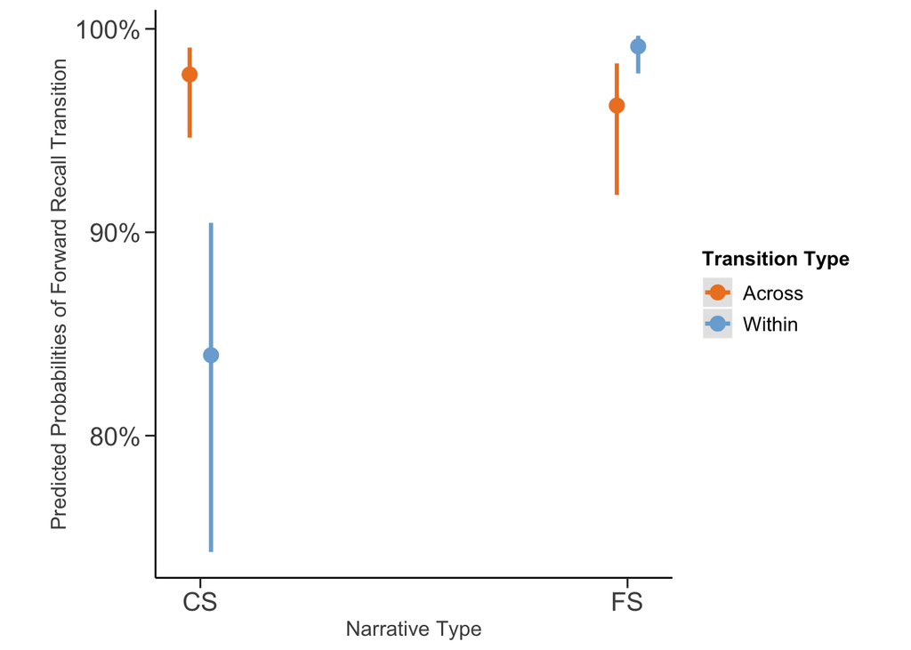

```r
# Plot contrasts - interaction between narrative_type and pair_type
plot_model(TransitionAccuracy_Intercept_model, type = "int", c("Transition_Type", "Narrative_Type"), legend.title = "Transition Type", colors = c("#EE8227", "#79ADD6"), dot.size = 3.5, line.size = 1.1, axis.labels = c("CS Narrative", "FS Narrative")) +
  theme(aspect.ratio = 1.1, axis.text = element_text(size = 13), axis.title = element_text(size = 11.5)) +
  #aes(color=group) +
  #font_size(axis_title.x = 13, axis_title.y = 13,labels.x = 14, labels.y = 14) +
  labs(title = NULL, x = "Narrative Type", y = "Predicted Probabilities of Forward Recall Transition", size = 8)
```

```r
emmean_TransitionAccuracy_summ <- emmeans(TransitionAccuracy_Intercept_model, specs = ~ Narrative_Type * Transition_Type)
summary(emmean_TransitionAccuracy_summ, type = "response")
```

|  | Narrative_Type | Transition_Type | prob | SE | df | asymp.LCL | asymp.UCL |
| --- | --- | --- | --- | --- | --- | --- | --- |
| 1 | CS | Across | 0.9775904 | 0.010010941 | Inf | 0.9468471 | 0.9907262 |
| 2 | FS | Across | 0.9623320 | 0.015299884 | Inf | 0.9178355 | 0.9831730 |
| 3 | CS | Within | 0.8395660 | 0.040854910 | Inf | 0.7427894 | 0.9046064 |
| 4 | FS | Within | 0.9913795 | 0.004099102 | Inf | 0.9782228 | 0.9966151 |

```r
# Set up comparisons
CS_across = c(1,0,0,0)
FS_across = c(0,1,0,0)
CS_within = c(0,0,1,0)
FS_within = c(0,0,0,1)
```

```r
# Planned Contrast
contrast(emmean_TransitionAccuracy_summ, method = list("CS_across - CS_within" = CS_across - CS_within,
                                         "FS_within - CS_within" = FS_within - CS_within),
         adjust = "none")
```

```
##  contrast              estimate    SE  df z.ratio p.value
##  CS_across - CS_within     2.12 0.372 Inf   5.707  <.0001
##  FS_within - CS_within     3.09 0.562 Inf   5.493  <.0001
##
## Results are given on the log odds ratio (not the response) scale.
```

```r
TransitionAccuracy_pairwise <- emmeans(TransitionAccuracy_Intercept_model, pairwise ~ Narrative_Type * Transition_Type, adjust = "none")
TransitionAccuracy_pairwise
```

```
## $emmeans
##  Narrative_Type Transition_Type emmean    SE  df asymp.LCL asymp.UCL
##  CS             Across            3.78 0.457 Inf      2.88      4.67
##  FS             Across            3.24 0.422 Inf      2.41      4.07
##  CS             Within            1.66 0.303 Inf      1.06      2.25
##  FS             Within            4.74 0.480 Inf      3.80      5.69
##
## Results are given on the logit (not the response) scale.
## Confidence level used: 0.95
##
## $contrasts
##  contrast              estimate    SE  df z.ratio p.value
##  CS Across - FS Across    0.535 0.615 Inf   0.870  0.3841
##  CS Across - CS Within    2.121 0.372 Inf   5.707  <.0001
##  CS Across - FS Within   -0.969 0.656 Inf  -1.478  0.1393
##  FS Across - CS Within    1.586 0.514 Inf   3.083  0.0020
##  FS Across - FS Within   -1.504 0.475 Inf  -3.169  0.0015
##  CS Within - FS Within   -3.090 0.562 Inf  -5.493  <.0001
##
## Results are given on the log odds ratio (not the response) scale.
```

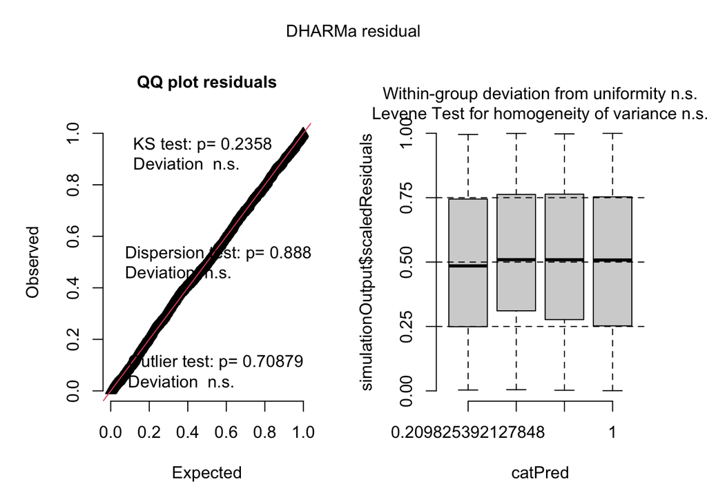

```r
simulationOutput_TransitionAccuracy <- simulateResiduals(fittedModel = TransitionAccuracy_Intercept_model, plot = F)
plot(simulationOutput_TransitionAccuracy)
```

### Supplemental: Serial Position Curve and lag-CRP (plotted using Psifr package in python)

3.2.1 Change the datafile into the required format for using Psifr package in python:

```r
recall_list25_data <- total_recall
recall_list25_data$Subject <- as.numeric(recall_list25_data$Subject)

# Fine-level_event: Rename column
recall_list25_data <- recall_list25_data %>%
  rename(item = `Fine-level_event`) %>%
  rename(subject = Subject) %>%
  rename(position = Recall_Order) %>%
  rename(coarse_index = `Coarse-level_index`) %>%
  rename(fine_subindex = `Fine-level_subindex`) %>%
  rename(fine_index = `Fine-level_index`) %>%
  mutate(trial_type = "recall")

recall_list25_data <- recall_list25_data %>%
  mutate(list = case_when(
    Narrative == "HC1_Aunt" ~ 1,
    Narrative == "HC2_Swimming" ~ 2,
    Narrative == "HC3_Morning" ~ 3,
    Narrative == "LC1_Shopping" ~ 4,
    Narrative == "LC2_Cleaning" ~ 5,
    Narrative == "LC3_Zoo" ~ 6,
    TRUE ~ 0
  ))


# Move column "subject" to the right-most position
recall_list25_data <- recall_list25_data %>%
  dplyr::select(-subject, everything(), subject)
```

```r
setwd("/Users/dcl/Library/CloudStorage/Box-Box/DCL_ARCHIVE/Documents/Events/exp165_TemporalOrder/Manuscript/Complete_Data/Data_Deidentification")

# Read in the narrative scripts
HC1_Aunt_study_raw <- read_excel("e165_Exp2_Recall_NarrativeList_Psifr.xlsx", sheet = "HC1_Aunt")
HC2_Swimming_study_raw <- read_excel("e165_Exp2_Recall_NarrativeList_Psifr.xlsx", sheet = "HC2_Swimming")
HC3_Morning_study_raw <- read_excel("e165_Exp2_Recall_NarrativeList_Psifr.xlsx", sheet = "HC3_Morning")
LC1_Shopping_study_raw <- read_excel("e165_Exp2_Recall_NarrativeList_Psifr.xlsx", sheet = "LC1_Shopping")
LC2_Cleaning_study_raw <- read_excel("e165_Exp2_Recall_NarrativeList_Psifr.xlsx", sheet = "LC2_Cleaning")
LC3_Zoo_study_raw <- read_excel("e165_Exp2_Recall_NarrativeList_Psifr.xlsx", sheet = "LC3_Zoo")
```

```r
sample_size = 32
# Define a function to turn each primitive studylist into real studylist in psifr
repeat_df <- function(study_df, sample_size){
  # repeat the study df for sample_size number of times
  stacked_df <- data.frame()
  for (i in 1:sample_size) {
    stacked_df <- rbind(stacked_df, study_df)
  }
  # create a column representing subject indexes
  subject_col <- rep(1:sample_size, each = 25)
  # bind subject column to the dataframe
  final_df <- cbind(stacked_df, subject = subject_col)
  return(final_df)
}

HC1_Aunt_study <- repeat_df(HC1_Aunt_study_raw, sample_size)
HC2_Swimming_study <- repeat_df(HC2_Swimming_study_raw, sample_size)
HC3_Morning_study <- repeat_df(HC3_Morning_study_raw, sample_size)
LC1_Shopping_study <- repeat_df(LC1_Shopping_study_raw, sample_size)
LC2_Cleaning_study <- repeat_df(LC2_Cleaning_study_raw, sample_size)
LC3_Zoo_study <- repeat_df(LC3_Zoo_study_raw, sample_size)

psifr_list <- rbind(recall_list25_data, HC1_Aunt_study, HC2_Swimming_study, HC3_Morning_study, LC1_Shopping_study, LC2_Cleaning_study, LC3_Zoo_study)

psifr_list <- psifr_list %>%
  arrange(desc(trial_type)) %>%
  dplyr::select(-List_index, -Coarse_List_index, -Fine_loc)

psifr_list_transition <- psifr_list
psifr_list_transition$coarse_event <- psifr_list_transition$list * 10 + psifr_list_transition$coarse_index * 1

# Filter out excluded trial
psifr_list_transition <- psifr_list_transition %>%
  filter(!(subject == 2 & Narrative == "HC1_Aunt"))

psifr_list_transition
```

| fine_index | fine_subindex | item | coarse_index | position | Narrative_Type | Narrative | Subject_Coarse_List_index | trial_type | list | subject | coarse_event |
| --- | --- | --- | --- | --- | --- | --- | --- | --- | --- | --- | --- |
| 1 | 1 | Take out the hoodie | 1 | 1 | CS | HC1_Aunt | NA | study | 1 | 1 | 11 |
| 2 | 2 | Check aunt's address | 1 | 2 | CS | HC1_Aunt | NA | study | 1 | 1 | 11 |
| 3 | 3 | Make sure the gift is wrapped | 1 | 3 | CS | HC1_Aunt | NA | study | 1 | 1 | 11 |
| 4 | 4 | Spray cologne on the neck | 1 | 4 | CS | HC1_Aunt | NA | study | 1 | 1 | 11 |
| 5 | 5 | Brush the hair | 1 | 5 | CS | HC1_Aunt | NA | study | 1 | 1 | 11 |
| 6 | 1 | Put the car sun visor down | 2 | 6 | CS | HC1_Aunt | NA | study | 1 | 1 | 12 |
| 7 | 2 | Turn on wipers to clean windshield | 2 | 7 | CS | HC1_Aunt | NA | study | 1 | 1 | 12 |
| 8 | 3 | Answer a phone call on bluetooth | 2 | 8 | CS | HC1_Aunt | NA | study | 1 | 1 | 12 |
| 9 | 4 | See the trees outside | 2 | 9 | CS | HC1_Aunt | NA | study | 1 | 1 | 12 |
| 10 | 5 | Lower the temperature of the AC | 2 | 10 | CS | HC1_Aunt | NA | study | 1 | 1 | 12 |

[output cut: 6998 more lines]

```r
# Export the psifr_list_transition to a CSV file
#write.csv(psifr_list_transition, file = "e165_Exp2_Recall_Transition_Psifr.csv", row.names = FALSE)
```